# Linear Bandits

Lin & James

### Linear Bandit Set-up

- Generalization of **Adversarial Bandits**
  - Set of arms {1, … ,K} \( \rightarrow \) compact set \( \mathcal{K} \subset \mathbb{R}^d \). Loss is a linear function of arms.
- **Parameters available to the player**:
  - Number of rounds \( n \)
  - Action set of the player \( \mathcal{K}\subset \mathbb{R}^d \)
  - Action set of the adversary \( \mathcal{L}\subset \mathbb{R}^d \)

### Linear Bandit Set-up

- **Game**: At each round \( t = 1,2,\dots,n \)
  1. Player choose \( x_t \in \mathcal{K} \)
  2. Adversary choose \( l_t \in \mathcal{L} \)
  3. At the end of round \( t \), player observe loss \( \langle x_t,l_t\rangle=x_t^Tl_t \)
- **Pseudo-regret** \[ \bar{R}_n = \mathbb{E}\sum_{t=1}^n x_t^Tl_t - \underset{x\in\mathcal{K}}{\mathrm{min}}\mathbb{E}\sum_{t=1}^n x^Tl_t \] (Expectation with respect to the forecaster's internal randomization)

### Example: Obstacle Course Problem

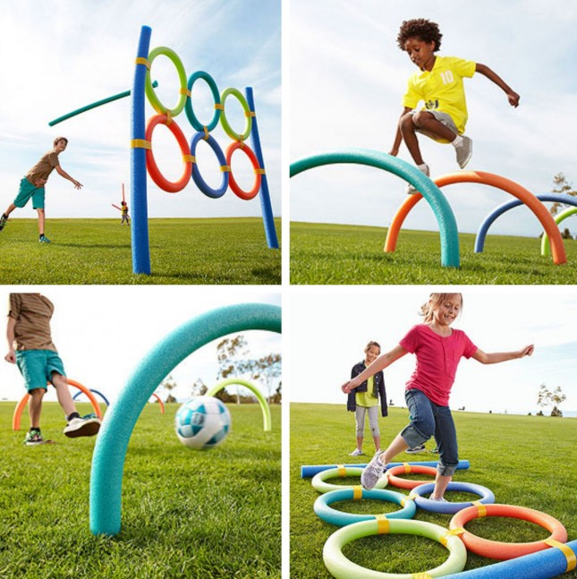

### Challenge: 5,000 kids to $5,000

- 33 obstacles with varying difficulty levels
- Each kid must complete 5
- Sending one kid at a time you choose their path
- 81 different paths
- Each path is a linear combination of 5 obstacles
- **Slowest team pays the fastest team $5,000**

Since you all are risk averse, like most people, you want to bound your regret.

### Strategy: Exp2 with John's Exploration

Need a non-deterministic strategy to play against the adversary.

- **Exp**anded **Exp**onential with John's Exploration
- **Bounded scalar loss** assumption:
  1. \( \mathcal{K} \) and \( \mathcal{L} \) are such that \( \lvert x^Tl \rvert \le 1, \forall (x,y)\in \mathcal{K}\times \mathcal{L} \)
  2. \( \mathcal{K} \) is finite with \( \lvert \mathcal{K}\rvert = N \) and \( \mathcal{K} \) spans \( \mathbb{R}^d \)
- John Ellipsoid \( \mathcal{E} \)
  - The John ellipsoid associated to a convex set \( \mathcal{K} \subset\mathbb{R}^d \) is the ellipsoid of minimal \( d \)-dimensional volume enclosing \( \mathcal{K} \).

### John's Theorem

- **Theorem 5.1**. Let \( \mathcal{K} \subset\mathbb{R}^d \) be a convex set. If the John ellipsoid \( \mathcal{E} \) is the **unit ball** in some norm derived from a scalar product \( \langle\cdot,\cdot\rangle \), then there exist \( M \le d(d+1)/2+1 \) **contact points** \( u_1,\dots,u_M \) between \( \mathcal{K} \) and \( \mathcal{E} \), and a **probability distribution** \( (\mu_1,\dots,\mu_M) \) over these contact points such that \[ x = d \sum_{i=1}^{M}\mu_i u_i \otimes u_i (x) \]
- (**Outer product**: \( x\otimes x(y) = \langle x,y\rangle x \))

The key idea is **select \( x_t \) at random** from some **prob. dist. \( p_t \)** over \( \mathcal{K} \). Since we do not directly observe \( l_t \), we need to find an estimate for it.

### Strategy: Exp2 with John's Exploration

- Define a \( d \times d \) matrix \[ P_t = \sum_{x\in\mathcal{K}}p_t(x) x \otimes x \]
- Unbiased estimate of \( l_t \): \( \tilde{l}_t = P_t^{-1}(x_t\otimes x_t)l_t \)  
  *Proof:*  
  \[ \begin{aligned} \mathbb{E}(\tilde{l}_t) &= \mathbb{E}(P_t^{-1}(x_t\otimes x_t)l_t)\\ &= P_t^{-1} \mathbb{E}(x_t\otimes x_t) l_t \\ &= P_t^{-1} [\sum_{x\in\mathcal{K}}p_t(x) x \otimes x] l_t \\ &= P_t^{-1} P_t l_t = l_t \end{aligned} \]

### Exp2 with John's Exploration

Input parameters \( \eta,\gamma > 0 \):  
For each round \( t = 1, 2, \dots, n \):

1. Player select \( x_t \) from \( p_t \).
2. Compute the estimate of \( l_t \)  
   \[ \tilde{l}_t = P_t^{-1}(x_t\otimes x_t)l_t \] Update the cummulative loss: \( \tilde{L}_t(x) = \sum_{s=1}^{t}\langle x_,\tilde{l}_s\rangle \)
3. Update the probability distribution over \( x \in \mathcal{K} \): \[ p_{t+1}(x) = (1-\gamma)\frac{\mathrm{exp}[-\eta \tilde{L}_t(x)]}{\sum_{y\in \mathcal{K}}\mathrm{exp}[-\eta \tilde{L}_t(y)]}+\gamma\sum_{i=1}^{M}\mu_i \mathbb{1}_{x=u_i} \]

### Pseudo-regret of Exp2-John

(**Thm 5.2**) . For any \( \eta,\gamma > 0 \) such that \( \eta d\le\gamma \), Exp2 with John's exploration satisfies \[ \bar{R_n} \le 2\gamma n + \frac{\mathrm{ln}(N)}{\eta} + \eta nd \] When \( \eta = \sqrt{\frac{\mathrm{ln}(N)}{3nd}} \) and \( \gamma = \eta d \), \[ \bar{R_n} \le 2\sqrt{3nd\mathrm{ln}{N}} \]

*Proof*: See the script.